# Assignment 7: PCoA & nMDS

#### PCoA: Bray-Curtis

```r
# response variable matrix
Y <- as.matrix(spider[,4:15])
# Distance/dissimilarity matrix with Bray-Curtis distances
spider.distBray <- vegdist(Y)
# PCoA on distance/dissimilarity matrix
spider.pcoaBray <- pcoa(spider.distBray)
```

```r
# eigenvalues, relative, and relative corrected eigenvalues
spider.pcoaBray$values[,1:3]
```

##### Scree Plot

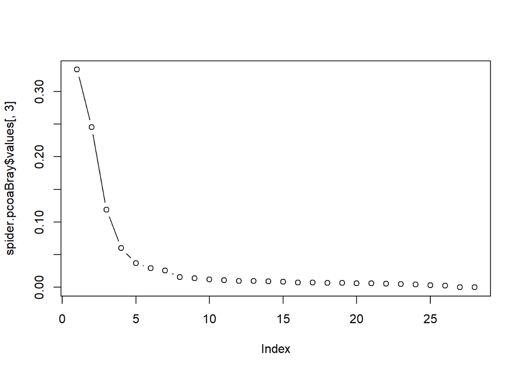

```r
# scree plot of relative corrected eigenvalues
plot(spider.pcoaBray$values[,3], type = "b")
```

This scree plot shows that the first three axes explain the majority of the variance in the original dataset (70%: PCoA1 = 33.4%, PCoA2 = 24.5%, PCoA3 = 11.9%), after which each additional axis only explains a small fraction.

```r
spider.pcoaBray$vectors[,1:3]
```

##### Axes 1 & 2

```r
plot.df.pcoaBray <- data.frame(
  axis1 = spider.pcoaBray$vectors[,1],
  axis2 = spider.pcoaBray$vectors[,2],
  axis3 = spider.pcoaBray$vectors[,3],
  bareSand = spider$bareSand,
  leafLitter = spider$leafLitter,
  reflection = spider$reflection)
```

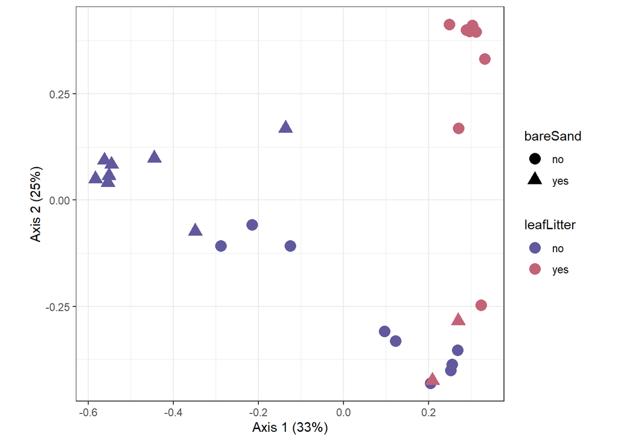

```r
p1 <- ggplot(data = plot.df.pcoaBray,
             mapping = aes(x = axis1, y = axis2,
                           color = leafLitter, shape = bareSand))+
  geom_point(size = 4) +
  coord_fixed() +
  xlab("Axis 1 (33%)") +
  ylab("Axis 2 (25%)") +
  scale_color_manual(values = pal1) +
  theme_bw()
p1
```

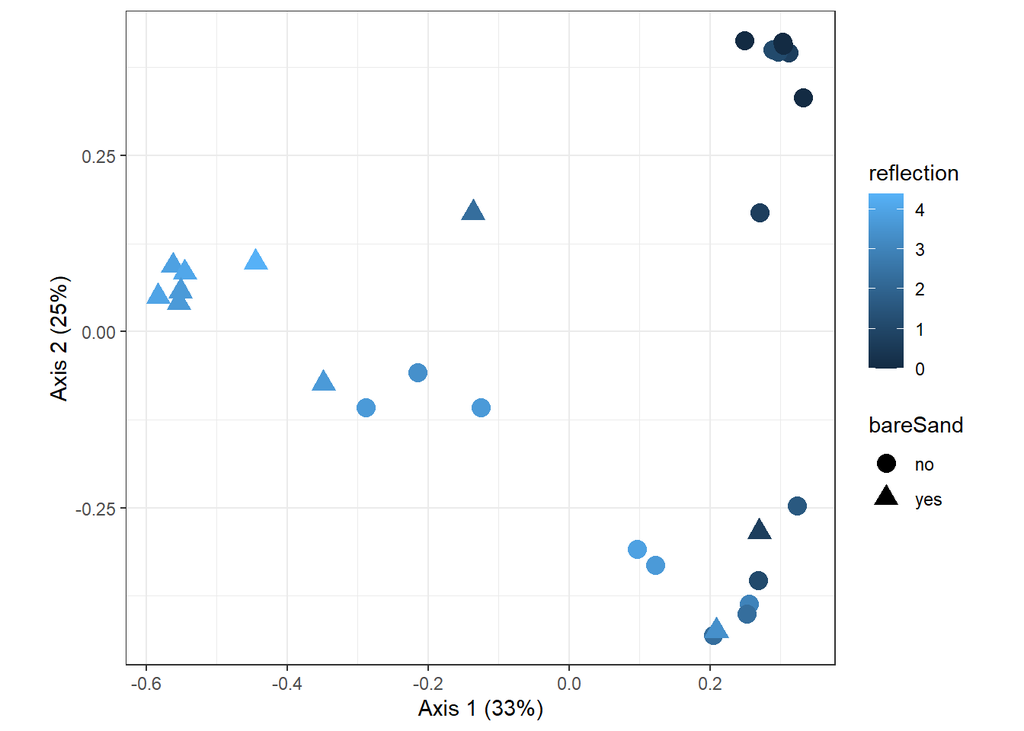

```r
p1.2 <- ggplot(data = plot.df.pcoaBray,
             mapping = aes(x = axis1, y = axis2,
                           color = reflection, shape = bareSand))+
  geom_point(size = 4) +
  coord_fixed() +
  xlab("Axis 1 (33%)") +
  ylab("Axis 2 (25%)") +
  theme_bw()
p1.2
```

##### Axes 1 & 3

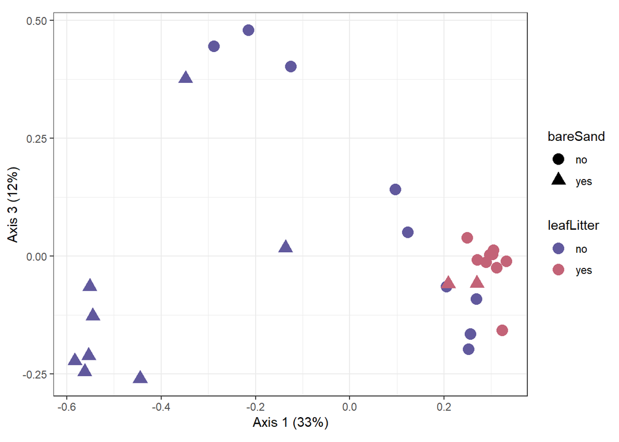

```r
p2 <- ggplot(data = plot.df.pcoaBray,
             mapping = aes(x = axis1, y = axis3,
                           color = leafLitter, shape = bareSand))+
  geom_point(size = 4) +
  coord_fixed() +
  xlab("Axis 1 (33%)") +
  ylab("Axis 3 (12%)") +
  scale_color_manual(values = pal1) +
  theme_bw()
p2
```

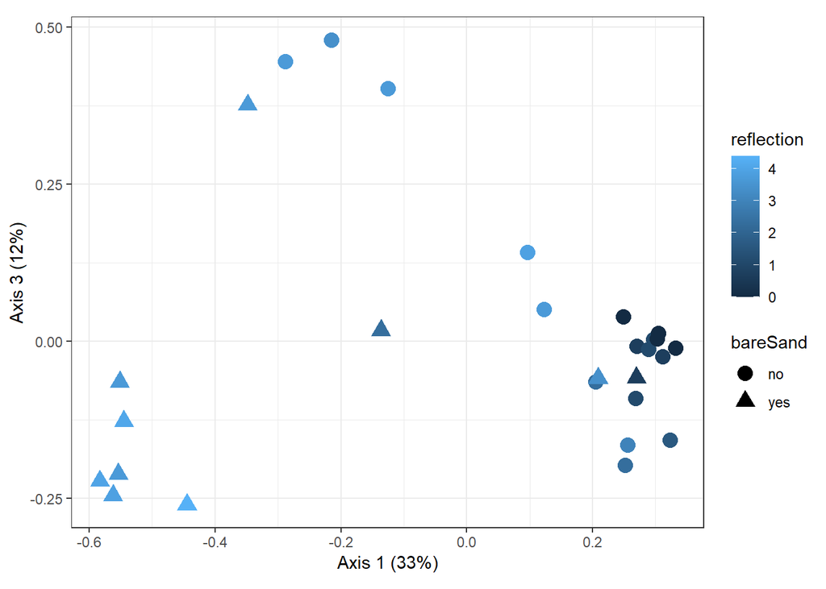

```r
p2.2 <- ggplot(data = plot.df.pcoaBray,
             mapping = aes(x = axis1, y = axis3,
                           color = reflection, shape = bareSand))+
  geom_point(size = 4) +
  coord_fixed() +
  xlab("Axis 1 (33%)") +
  ylab("Axis 3 (12%)") +
  theme_bw()
p2.2
```

##### Axes 2 & 3

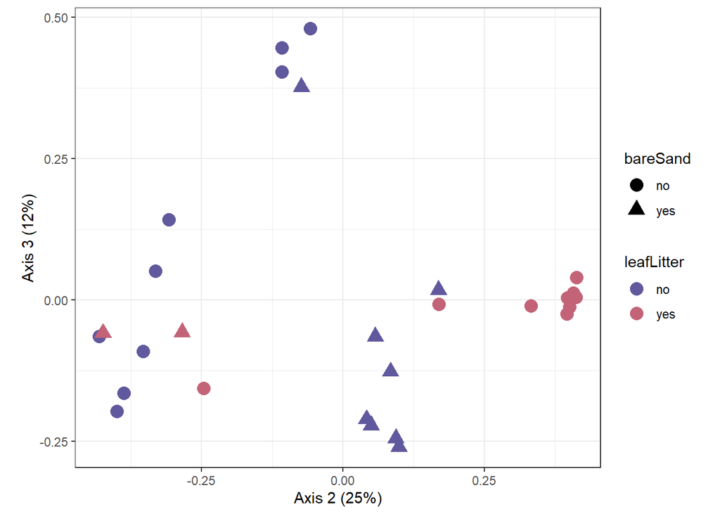

```r
p3 <- ggplot(data = plot.df.pcoaBray,
             mapping = aes(x = axis2, y = axis3,
                           color = leafLitter, shape = bareSand))+
  geom_point(size = 4) +
  coord_fixed() +
  xlab("Axis 2 (25%)") +
  ylab("Axis 3 (12%)") +
  scale_color_manual(values = pal1) +
  theme_bw()
p3
```

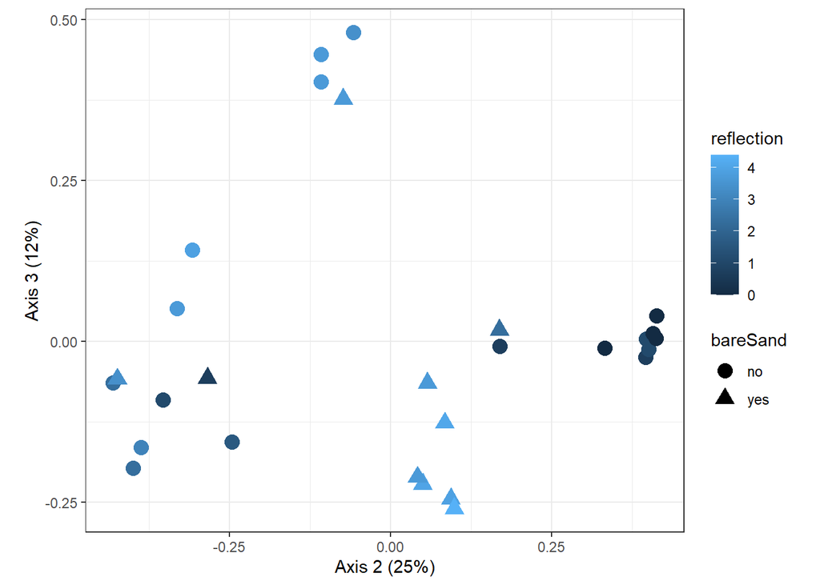

```r
p3.2 <- ggplot(data = plot.df.pcoaBray,
             mapping = aes(x = axis2, y = axis3,
                           color = reflection, shape = bareSand))+
  geom_point(size = 4) +
  coord_fixed() +
  xlab("Axis 2 (25%)") +
  ylab("Axis 3 (12%)") +
  theme_bw()
p3.2
```

## Cluster Analysis

I used hierarchical clustering with Ward’s linkage to determine if the spider communities naturally grouped based on species abundances. Ward’s linkage is an agglomerative algorithm that minimizes the variance among points in a group, making it a good choice for these data. After visualizing the clusters with a dendrogram, I decided to cut the tree at k = 4 with four clusters, since four fairly distinct groups arise at a distance of approximately 0.75 - 1. An equivocal method would be to cut the tree with h = 1.

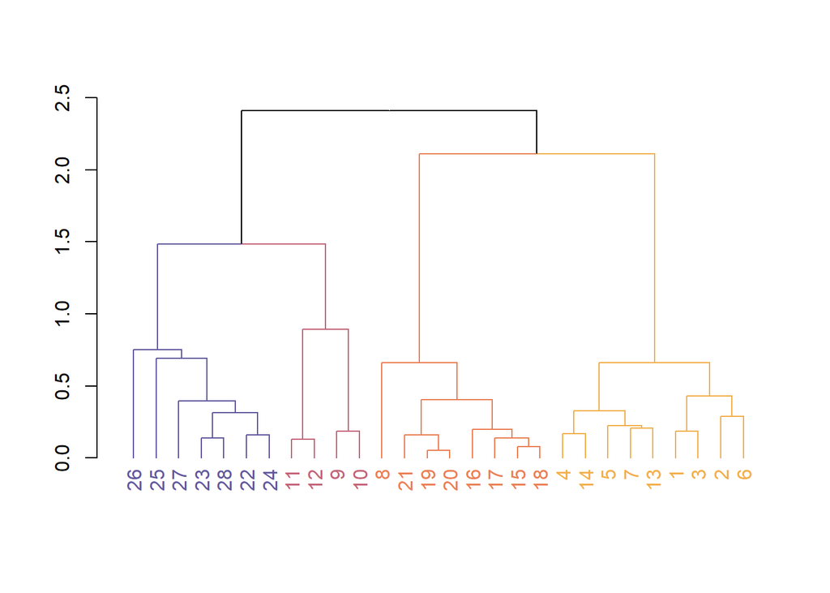

```r
spider.hcl <- hclust(spider.distBray, "ward.D2")
spider.dend <- as.dendrogram(spider.hcl)
pal2 <- pnw_palette("Sunset2", n = 4)

spider.dend <- spider.dend |>
  color_branches(k = 4, col = pal2) |>
  color_labels(k = 4, col = pal2)

plot(spider.dend)
```

Four groups arise in the cluster analysis, as shown by the color of branches and sample numbers. Since the groups all cluster below a distance of 1, and the next highest grouping is at a distance of 1.5, I am fairly confident in cutting the tree at four clusters.

# Results

```r
spider.cut <- as.factor(cutree(spider.hcl, k = 4))
spider.scores <- as.data.frame(wascores(spider.pcoaBray$vectors, spider[,-c(1:3)]))
rownames(spider.scores)
```

```
##  [1] "Alopacce" "Alopcune" "Alopfabr" "Arctlute" "Arctperi" "Auloalbi"
##  [7] "Pardlugu" "Pardmont" "Pardnigr" "Pardpull" "Trocterr" "Zoraspin"
```

```r
plot.df.pcoaBray <- data.frame(
  axis1 = spider.pcoaBray$vectors[,1],
  axis2 = spider.pcoaBray$vectors[,2],
  axis3 = spider.pcoaBray$vectors[,3],
  bareSand = spider$bareSand,
  leafLitter = spider$leafLitter,
  reflection = spider$reflection,
  cluster = spider.cut)
```

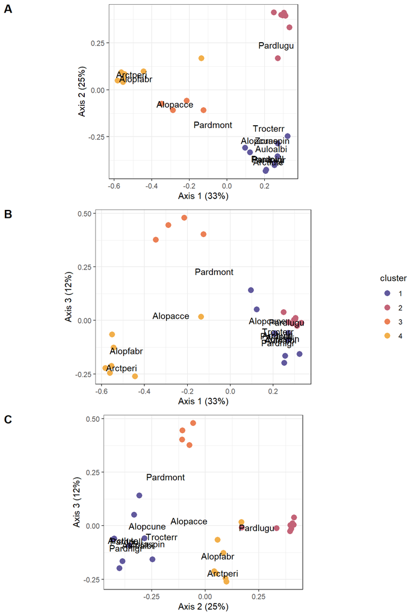

```r
p1 <- ggplot()+
  geom_point(size = 3,data = plot.df.pcoaBray,
             mapping = aes(x = axis1, y = axis2,
                           color = cluster)) +
  coord_fixed() +
  xlab("Axis 1 (33%)") +
  ylab("Axis 2 (25%)") +
  scale_color_manual(values = pal2) +
  theme_bw() +
  geom_text(data = spider.scores, aes(x = Axis.1, y = Axis.2), label = rownames(spider.scores))

p1.2 <- ggplot()+
  geom_point(size = 3, data = plot.df.pcoaBray,
             mapping = aes(x = axis1, y = axis3,
                           color = cluster)) +
  coord_fixed() +
  xlab("Axis 1 (33%)") +
  ylab("Axis 3 (12%)") +
  scale_color_manual(values = pal2) +
  theme_bw() +
  geom_text(data = spider.scores, aes(x = Axis.1, y = Axis.3), label = rownames(spider.scores))

p1.3 <- ggplot()+
  geom_point(size = 3, data = plot.df.pcoaBray,
             mapping = aes(x = axis2, y = axis3,
                           color = cluster)) +
  coord_fixed() +
  xlab("Axis 2 (25%)") +
  ylab("Axis 3 (12%)") +
  scale_color_manual(values = pal2) +
  theme_bw() +
  geom_text(data = spider.scores, aes(x = Axis.2, y = Axis.3), label = rownames(spider.scores))


ggarrange(p1, p1.2, p1.3, ncol = 1,
             labels = c("A", "B", "C"),
             common.legend=TRUE, legend = "right")
```

**Figure 1.** PCoA ordination plots of spider community data showing the first Principle Coordinate axis (33% of variance explained), second axis (25%) and third axis (12%). Colors show clusters identified with hierarchical clustering using Ward’s linkage, k = 4. (A) PCoA 1 (x axis) and PCoA 2 (y axis). (B) PCoA 1 (x axis) and PCoA 3 (y axis). (C) PCoA 2 (x axis) and PCoA 3 (y axis).

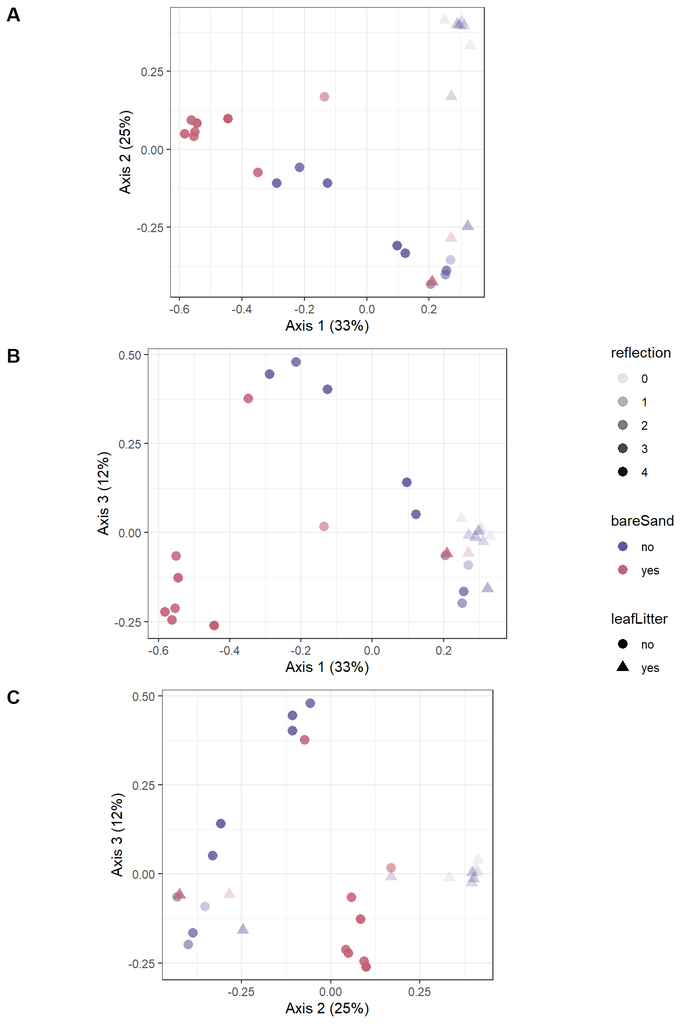

```r
p2 <- ggplot(data = plot.df.pcoaBray,
             mapping = aes(x = axis1, y = axis2,
                           color = bareSand,
                           shape = leafLitter,
                           alpha = reflection))+
  geom_point(size = 3) +
  coord_fixed() +
  xlab("Axis 1 (33%)") +
  ylab("Axis 2 (25%)") +
  scale_color_manual(values = pal2) +
  theme_bw()

p2.2 <- ggplot(data = plot.df.pcoaBray,
             mapping = aes(x = axis1, y = axis3,
                           color = bareSand,
                           shape = leafLitter,
                           alpha = reflection))+
  geom_point(size = 3) +
  coord_fixed() +
  xlab("Axis 1 (33%)") +
  ylab("Axis 3 (12%)") +
  scale_color_manual(values = pal2) +
  theme_bw()

p2.3 <- ggplot(data = plot.df.pcoaBray,
             mapping = aes(x = axis2, y = axis3,
                           color = bareSand,
                           shape = leafLitter,
                           alpha = reflection))+
  geom_point(size = 3) +
  coord_fixed() +
  xlab("Axis 2 (25%)") +
  ylab("Axis 3 (12%)") +
  scale_color_manual(values = pal2) +
  theme_bw()

ggarrange(p2, p2.2, p2.3, ncol = 1,
             labels = c("A", "B", "C"),
             common.legend=TRUE, legend = "right")
```

**Figure 2.** PCoA ordination plots of spider community data showing the first Principle Coordinate axis (33% of variance explained), second axis (25%), and third axis (12%). Opacity shows reflection (transparent = low reflection, solid = high reflection), color shows bare sand presence/absence, and shape shows leaf litter presence/absence. (A) PCoA 1 (x axis) and PCoA 2 (y axis). (B) PCoA 1 (x axis) and PCoA 3 (y axis). (C) PCoA 2 (x axis) and PCoA 3 (y axis).

# Discussion

This Principle Coordinates Analysis, using Bray-Curtis distance/dissimilarity measures, explains 70% of the variance within the spider community data across the first three axes, providing a decent explanation of the variation in species abundance between sites. Spider communities separated into four identifiable clusters with hierarchical clustering using Ward’s linkage. These clusters are well distinguished along the first three PCoA axes. Reflection, bare sand presence/absence, and leaf litter show some patterns among sites that coincide - though not perfectly - with groups identified in the cluster analysis.

## Figure 2

Figure 2 shows less clear but nonetheless interesting patterns with the external variables. Communities with leaf litter present (triangle shapes) have consistently positive scores on PCoA 1, coinciding with lower reflection values (more transparent). Most bare sand-absent communities have positive scores along PCoA 1 and bare sand-present communities show negative scores, although there is some overlap near 0. Axis 2 delineates points at high PCoA 1 scores, somewhat aligning with reflection but otherwise not aligning with any of the variables plotted. Axis 3 pulls four communities apart from the rest, but they do not have any particular variable that is unique to them.

# Conclusions

Hunting spider communities do show observable patterns in their species abundances and cluster into four groups. The environmental variables of reflection, bare sand presence/absence, and leaf litter presence/absence align roughly with some of these groups, but at least one shows a mix of all environmental variables. This suggests that while reflection and habitat type explain some of the variation between spider communities, there are other factors at work.

Spider communities could be further distinguished by mapping the original species (or species with the strongest influence over the PCoA axes) onto the ordination plots to help with interpretation of the axes.

# Reflection

I think I understand PCoA well - I would like to run this through with nMDS as well before the final assignment to compare those ordinations and see if nMDS provides a better plot. I was a little unsure if the straight Euclidean distance PCoA was even worth including, but I ultimately did because it was quite different from the standardized Euclidean PCoA and exemplified how not using an appropriate distance measure can give misleading results.

After class today, I would also like to map the species scores back onto the plots and reassess the groups I found with clustering, but I do not have time this evening to add it to the draft.